# Introduction to Factorial Designs Problem Set

## 2.2 Analysis

Your results are in blocking.csv .

```r
# For future reference how this was built
# myDF <- data.frame(Tank = rep(c('1 x tank co', '1 x tank co', '2 x tank co', '2 x tank co'), 3),
#                    AFV = rep(c('1 x AFV co', '2 x AFV co', '1 x AFV co', '2 x AFV co'), 3),
#                    Machine = c(rep('yzma', 4), rep('cruella', 4), rep('lex', 4)))
#
# #myDF$error <- round(rnorm(12, 0, 2), 0)
# myDF <- myDF %>%
#   mutate(Kills = round(13 + ifelse(Tank == '2 x tank co', 5, 0) + ifelse(AFV == '2 x AFV co', 8, 0) + rnorm(12, 0, 2), 0))
# myDF$Kills[myDF$Tank == '1 x tank co' & myDF$AFV == '1 x AFV co'] <- myDF$Kills[myDF$Tank == '1 x tank co' & myDF$AFV == '1 x AFV co']-2
# write.csv(select(myDF, -error), './blocking.csv', row.names = F)
```

1. Read / format your data

```r
fs <- read.csv('blocking.csv')
fs$Tank <- as.factor(fs$Tank)
fs$AFV <- as.factor(fs$AFV)
fs$Machine <- as.factor(fs$Machine)
```

2. Visualize Your Data

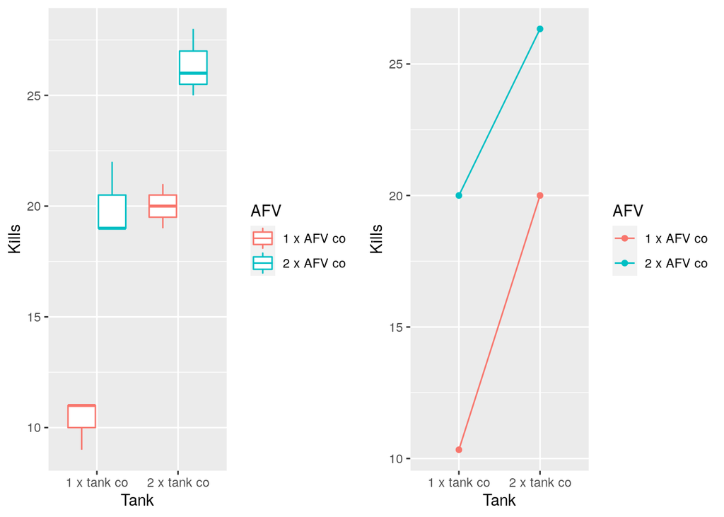

```r
ggpubr::ggarrange(
  ggplot(fs, aes(x = Tank, y = Kills, color = AFV)) +
    geom_boxplot(),
  ggplot(fs, aes(x = Tank, y = Kills, color = AFV, group = AFV)) +
    stat_summary(fun = 'mean', geom = 'line') +
    stat_summary(fun = 'mean', geom = 'point'),
  nrow = 1)
```

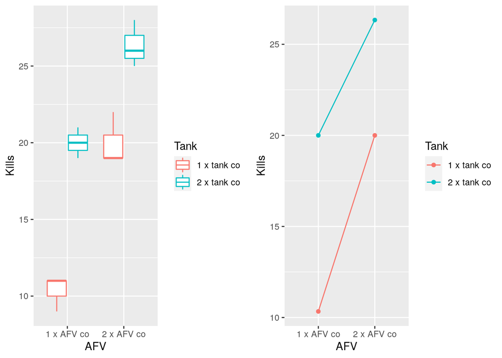

```r
ggpubr::ggarrange(
  ggplot(fs, aes(x = AFV, y = Kills, color = Tank)) +
    geom_boxplot(),
  ggplot(fs, aes(x = AFV, y = Kills, color = Tank, group = Tank)) +
    stat_summary(fun = 'mean', geom = 'line') +
    stat_summary(fun = 'mean', geom = 'point'),
  nrow = 1)
```

```r
# It certainly appears that there is an effect of adding companies
# but it does not appear that there is an interaction effect
# Potentially hard to say if one has a greater effect than the other
```

3. Analyze the Data

Conduct, assess, and interpret an ANOVA that accounts for potential factor interaction (i.e. Tank:AFV), accounts for the block, but assumes there is no interaction between the block and the factors. Use $\alpha = .01$ for your significance.

```r
# We can set up our ANOVA with the model y = mu + tau + beta + tau:beta + block + error
myAOV <- aov(Kills ~ Tank + AFV + Tank:AFV + Machine, data = fs)

summary(myAOV)
```

```
##             Df Sum Sq Mean Sq F value   Pr(>F)
## Tank         1 192.00  192.00  78.545 0.000115 ***
## AFV          1 192.00  192.00  78.545 0.000115 ***
## Machine      2   0.67    0.33   0.136 0.875154
## Tank:AFV     1   8.33    8.33   3.409 0.114364
## Residuals    6  14.67    2.44
## ---
## Signif. codes:  0 '***' 0.001 '**' 0.01 '*' 0.05 '.' 0.1 ' ' 1
```

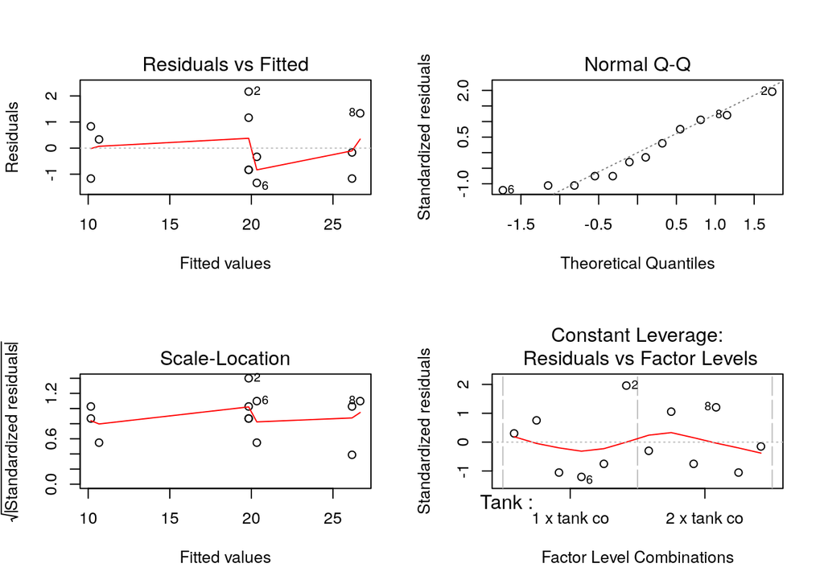

```r
# This shows us that both the tank and AFV are significant at alpha = .01
# The machine has no apparent effect
# The interaction is also not significant

par(mfrow = c(2,2))
plot(myAOV)
```

```r
# our plots appear to meet our assumptions
shapiro.test(myAOV$residuals)
```

```
##
##  Shapiro-Wilk normality test
##
## data:  myAOV$residuals
## W = 0.91952, p-value = 0.282
```

```r
# We pass the shapiro wilk test

lawstat::levene.test(fs$Kills, fs$Tank)
```

```
##
##  Modified robust Brown-Forsythe Levene-type test based on the absolute
##  deviations from the median
##
## data:  fs$Kills
## Test Statistic = 5.3191, p-value = 0.04378
```

```r
lawstat::levene.test(fs$Kills, fs$AFV)
```

```
##
##  Modified robust Brown-Forsythe Levene-type test based on the absolute
##  deviations from the median
##
## data:  fs$Kills
## Test Statistic = 5.1546, p-value = 0.04654
```

```r
# We pass homogenity of variance across both groups

# I don't know if we need to just test by the lowest level of groups...
lawstat::levene.test(fs$Kills, mutate(fs, group = as.factor(paste(Tank, AFV)))$group)
```

```
##
##  Modified robust Brown-Forsythe Levene-type test based on the absolute
##  deviations from the median
##
## data:  fs$Kills
## Test Statistic = 0.078431, p-value = 0.9699
```

```r
# We can say that adding more armored vehicles (tanks or AFVs) is significant,
# but it does not appear that there is any synergy there
```

4. Estimate the Effects

Estimate the treatment effects for your significant factors

```r
grand.mean <- mean(fs$Kills)

# We calclualate our treatment effects for each of the two significant levels
tau.1 <- mean(fs$Kills[fs$Tank == '1 x tank co']) - grand.mean
tau.2 <- mean(fs$Kills[fs$Tank == '2 x tank co']) - grand.mean
beta.1 <- mean(fs$Kills[fs$AFV == '1 x AFV co']) - grand.mean
beta.2 <- mean(fs$Kills[fs$AFV == '2 x AFV co']) - grand.mean

# We can further estimate the sd of the error by doing an ANOVA using this model
myAOV.ME <- aov(Kills ~ Tank + AFV, data = fs)
error.sd <- sd(myAOV.ME$residuals)
```

Write out your model:

$$Kills = 19.2 + \tau_i + \beta_j + \epsilon_{ijk}$$

Where:

- $\tau_{1 x tank} = -4$
- $\tau_{2 x tank} = 4$
- $\beta_{1 x AFV} = -4$
- $\beta_{2 x AFV} = 4$
- $\epsilon_{ijk} \sim N(0, 2.2)$
[^1]: Something to do with how the simulation is compiled. Go figure.